# Bend it like Beckham

by Will Nguyen

[figure not shown]

## Introduction

Odell Cornelious Beckham Jr. (OBJ) was drafted by the New York Giants 12th overall in the 2014 NFL draft from LSU. Famous for his one-handed touchdown catch against the Dallas Cowboys, Odell had a phenomenal debut season setting NFL records on his way to a 2014 Offensive Rookie of the Year award. After 5 years with the Giants, Odell briefly played with the Cleveland Browns before winning a Super Bowl with the LA Rams. He is now on the Baltimore Ravens after recovering from an ACL injury.

But just how good was Odell as a New York Giant?

This statistical analysis will focus on comparing Odell's performances as a wide receiver since entering the league and until he left New York. I will be focusing this analysis on WR metrics relating to recieving yards, receptions, and touchdowns.

I will be using Python to scrape, clean, and analyze wide receiver statistics from 2014 through 2018. All data is from pro-football-reference.com.

## Data Scraping

Standard importing of necessary/used libraries for scraping, storing, manipulating, and plottig the data.

```python
import pandas as pd
import numpy as np
import matplotlib.pyplot as plt
import seaborn
from bs4 import BeautifulSoup
import requests
import warnings
import sklearn
from sklearn.linear_model import LinearRegression

warnings.filterwarnings('ignore')
```

## Source

This project utilizes data from **[pro-football-reference](https://www.pro-football-reference.com/years/2014/receiving.htm)**. Because the data we want is organized on their own page by year (and the url is non-encrypted), we can use loops to scrape the receiving data from 2014 through to 2018.

Even though there are a lot of stats that I don't need, I'll first scrape the entire page and put it into a table to filter later. I also added a column indicating the year that player's stats were recorded.

```python
url = "https://www.pro-football-reference.com/years/2014/receiving.htm"
dfs = []

for i in range(2014, 2019):
    # pulls page and finds table with stats
    re = requests.get(url)
    root = BeautifulSoup(re.content)
    t = root.find("table")

    # convert to dataframe and show what year stats are from
    df = pd.read_html(str(t))[0]
    df["year"] = [i for k in range(0, df["GS"].count())]

    dfs.append(df)
    url = url.replace(str(i), str(i+1))
```

## Data Filtering and Cleaning

I also convert any data that appears to be a number, but is actually a string, and remove any unwanted columns before combining each of the yearly tables into a single table.

```python
wr = []
for i in range(0, len(dfs)):
    df = dfs[i]
    # remove repeat column titles
    df = df[~df["Rk"].str.contains("Rk")]

    # filter for wrs
    df = df[df["Pos"]=="WR"]

    # filter for top 32 wrs (WR1)
    df["Rk"] = pd.to_numeric(df["Rk"])

    # convert from string to numbers
    df["TD"] = pd.to_numeric(df["TD"])
    df["Tgt"] = pd.to_numeric(df["Tgt"])
    df["Rec"] = pd.to_numeric(df["Rec"])
    df["Yds"] = pd.to_numeric(df["Yds"])
    df["Player"] = df["Player"].astype('string')

    df = df[df["Rk"] < 33]
    wr.append(df)
```

```python
# combine tables from each year
table = wr[0]
for i in range(1, len(wr)):
    table = table.append(wr[i])

table = table[["Player", "GS", "Tgt", "Rec", "Ctch%", "Yds", "Y/R", "TD", "Y/Tgt", "R/G", "Y/G", "year"]]
```

Next steps are to calculate any desired metrics that weren't include from pro-football-reference.

```python
names = []
catch = []
tar_g = []
rec_g = []
yrds_g = []
yrds_t = []
yrds_r = []

for x in table.itertuples():
    # remove Pro Bowl and AP indicators
    names.append(x[1].replace("*", "").replace("+", "").strip())

    # fix catch%
    catch.append(x[5].replace("%", ""))

    # convert other "per" metrics
    tar_g.append(int(x[3])/int(x[2]))
    rec_g.append(int(x[4])/int(x[2]))
    yrds_g.append(int(x[6])/int(x[2]))
    yrds_t.append(int(x[6])/int(x[3]))
    yrds_r.append(int(x[6])/int(x[4]))

table["Player"] = names
table["rec"] = x[4]
table["catch_rate"] = catch
table["tar/g"] = tar_g
table["rec/g"] = rec_g
table["yrds/g"] = yrds_g
table["yrds/t"] = yrds_t
table["yrds/r"] = yrds_r

table['catch_rate'] = table['catch_rate'].astype(float)/100
table.drop(['GS', 'Ctch%', 'rec','Y/R', 'Y/Tgt', 'R/G', 'Y/G'], axis=1, inplace = True)
table = table[[col for col in table if col not in ["year"]] + ["year"]]
```

```python
table = table.rename(columns = {"Tgt": "tar", "Rec": "rec", "Yds": "yrds", "TD": "td"})
```

```python
table.head(10)
```

|  | Player | tar | rec | yrds | td | catch_rate | tar/g | rec/g | yrds/g | yrds/t | yrds/r | year |
| --- | --- | --- | --- | --- | --- | --- | --- | --- | --- | --- | --- | --- |
| 0 | Antonio Brown | 181.0 | 129 | 1698 | 13 | 0.713 | 11.312500 | 8.062500 | 106.125000 | 9.381215 | 13.162791 | 2014 |
| 1 | Demaryius Thomas | 184.0 | 111 | 1619 | 11 | 0.603 | 11.500000 | 6.937500 | 101.187500 | 8.798913 | 14.585586 | 2014 |
| 2 | Julio Jones | 163.0 | 104 | 1593 | 6 | 0.638 | 10.866667 | 6.933333 | 106.200000 | 9.773006 | 15.317308 | 2014 |
| 4 | Emmanuel Sanders | 141.0 | 101 | 1404 | 9 | 0.716 | 8.812500 | 6.312500 | 87.750000 | 9.957447 | 13.900990 | 2014 |
| 5 | Golden Tate | 144.0 | 99 | 1331 | 4 | 0.688 | 9.000000 | 6.187500 | 83.187500 | 9.243056 | 13.444444 | 2014 |
| 6 | Jordy Nelson | 151.0 | 98 | 1519 | 13 | 0.649 | 9.437500 | 6.125000 | 94.937500 | 10.059603 | 15.500000 | 2014 |
| 7 | Julian Edelman | 134.0 | 92 | 972 | 4 | 0.687 | 10.307692 | 7.076923 | 74.769231 | 7.253731 | 10.565217 | 2014 |
| 8 | Odell Beckham Jr. | 130.0 | 91 | 1305 | 12 | 0.700 | 11.818182 | 8.272727 | 118.636364 | 10.038462 | 14.340659 | 2014 |
| 9 | Randall Cobb | 127.0 | 91 | 1287 | 12 | 0.717 | 7.937500 | 5.687500 | 80.437500 | 10.133858 | 14.142857 | 2014 |
| 11 | Dez Bryant | 136.0 | 88 | 1320 | 16 | 0.647 | 8.500000 | 5.500000 | 82.500000 | 9.705882 | 15.000000 | 2014 |

# Data Visualizations and Analysis

Now that we have our finished table, here is a breakdown of what data each column contains.

1. **Player**: player's name
2. **tar**: "targets", number of times targeted with a pass
3. **rec**: "receptions", number of catches
4. **yrds**: "yards", number of receving yards
5. **td**: "touchdowns", number of touchdown receptions made
6. **catch_rate**: percentage of targets caught
7. **tar/g**: "targets per game"
8. **rec/g**: "receptions per game"
9. **yrds/g**: "yards per game"
10. **yrds/t**: "yards per target"
11. **yrds/r**: "yards per reception"
12. **year**: year stats were recorded

Now, lets look at some graphs to get an idea of how Odell fares amongst the top receivers each year, starting with yrds/g vs rec/g.

**Odell spent most of 2017 injured, playing 4 games and started 2.**

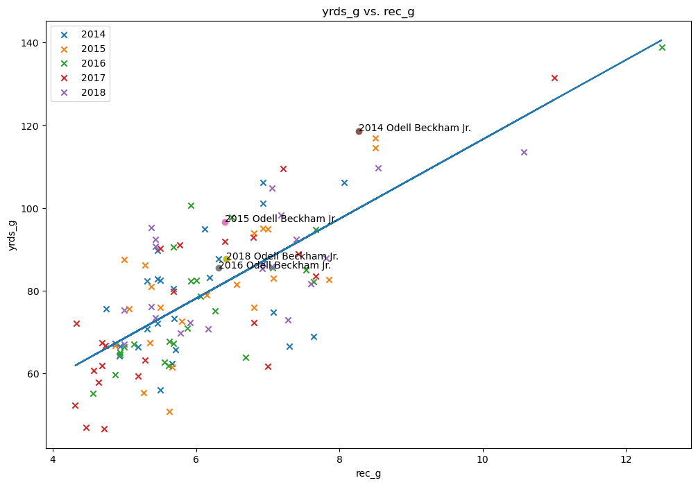

```python
plt.subplots(figsize = (12, 8))

i = 2014
for y in table["year"].unique():
    year = table[(table==y).any(axis=1)]
    year = year[~year["Player"].str.contains("Odell Beckham Jr.")]

    plt.scatter(marker="x", x=year["rec/g"], y=year["yrds/g"], label=str(i))
    i+=1

plt.legend()

for x in table.itertuples():
    name = x[1]
    # (y) yards per game [9] vs (x) receptions per game [8]
    yrds_g = x[9]
    rec_g = x[8]
    if(name == "Odell Beckham Jr."):
        plt.scatter(marker="o", x=x[8], y=x[9])
        plt.annotate(str(x[12]) + " " + x[1], (x[8], x[9]))

yrds_reg = np.array(table["yrds/g"]).reshape(-1, 1)
rec_reg = np.array(table["rec/g"]).reshape(-1, 1)

reg = LinearRegression().fit(rec_reg, yrds_reg)
plt.plot(rec_reg, reg.intercept_ + reg.coef_ * rec_reg, '-')

x = "rec_g"
y = "yrds_g"
plt.xlabel(x)
plt.ylabel(y)
plt.title(y + " vs. " + x)
plt.show()
```

This chart provides insights into the efficiency of the receiver by showing how many yards they gain on average for each reception.

As you can see, Odell consistently performed above average in terms of yrds/g vs rec/g, with 2014 being his best performance in this metric.

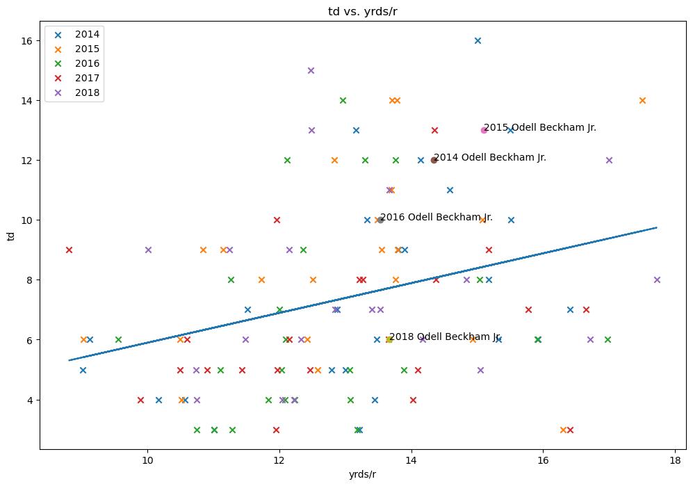

```python
plt.subplots(figsize = (12, 8))

xvar = "yrds/r"
yvar = "td"

i = 2014
for y in table["year"].unique():
    year = table[(table==y).any(axis=1)]
    year = year[~year["Player"].str.contains("Odell Beckham Jr.")]

    plt.scatter(marker="x", x=year[xvar], y=year[yvar], label=str(i))
    i+=1

plt.legend()

for x in table.itertuples():
    name = x[1]
    # y var vs x var
    xvar2 = x[11]
    yvar2 = x[5]
    if(name == "Odell Beckham Jr."):
        plt.scatter(marker="o", x=x[11], y=x[5])
        plt.annotate(str(x[12]) + " " + x[1], (x[11], x[5]))

xvar_reg = np.array(table[xvar]).reshape(-1, 1)
yvar_reg = np.array(table[yvar]).reshape(-1, 1)

reg = LinearRegression().fit(xvar_reg, yvar_reg)
plt.plot(xvar_reg, reg.intercept_ + reg.coef_ * xvar_reg, '-')

plt.xlabel(xvar)
plt.ylabel(yvar)
plt.title(yvar + " vs. " + xvar)
plt.show()
```

This graph analyzes big-play ability by showing how many yards they gain on average for each reception and its correlation with touchdown count.

Against, Odell performs above the pack, with his last season with the Giants being his only one below average. This also matches with his reputation as a playmaker.

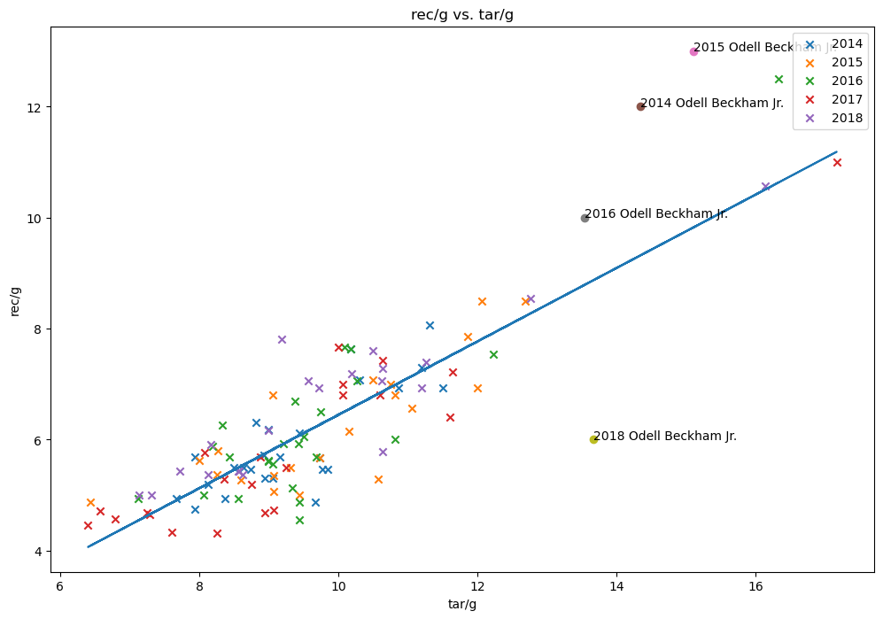

```python
plt.subplots(figsize = (12, 8))

xvar = "tar/g"
yvar = "rec/g"

i = 2014
for y in table["year"].unique():
    year = table[(table==y).any(axis=1)]
    year = year[~year["Player"].str.contains("Odell Beckham Jr.")]

    plt.scatter(marker="x", x=year[xvar], y=year[yvar], label=str(i))
    i+=1

plt.legend()

for x in table.itertuples():
    name = x[1]
    # y var vs x var
    xvar2 = x[11]
    yvar2 = x[5]
    if(name == "Odell Beckham Jr."):
        plt.scatter(marker="o", x=x[11], y=x[5])
        plt.annotate(str(x[12]) + " " + x[1], (x[11], x[5]))

xvar_reg = np.array(table[xvar]).reshape(-1, 1)
yvar_reg = np.array(table[yvar]).reshape(-1, 1)

reg = LinearRegression().fit(xvar_reg, yvar_reg)
plt.plot(xvar_reg, reg.intercept_ + reg.coef_ * xvar_reg, '-')

plt.xlabel(xvar)
plt.ylabel(yvar)
plt.title(yvar + " vs. " + xvar)
plt.show()
```

This graph provides insights into a receiver's effectiveness at converting targets into actual receptions.

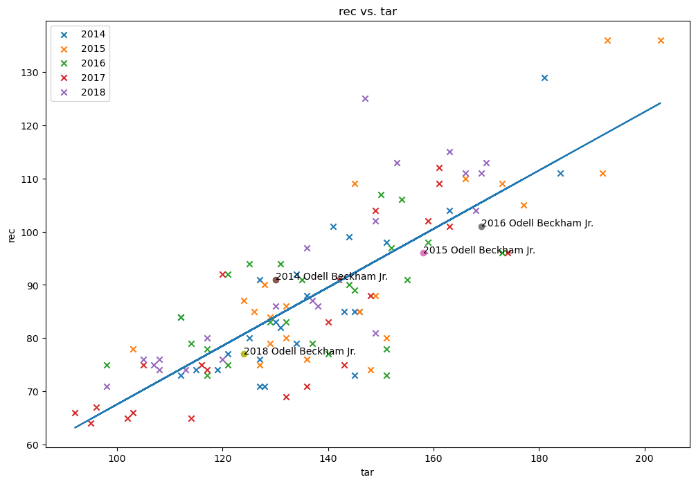

```python
plt.subplots(figsize = (12, 8))

xvar = "tar"
yvar = "rec"

i = 2014
for y in table["year"].unique():
    year = table[(table==y).any(axis=1)]
    year = year[~year["Player"].str.contains("Odell Beckham Jr.")]

    plt.scatter(marker="x", x=year[xvar], y=year[yvar], label=str(i))
    i+=1

plt.legend()

for x in table.itertuples():
    name = x[1]
    # y var vs x var
    xvar2 = x[2]
    yvar2 = x[3]
    if(name == "Odell Beckham Jr."):
        plt.scatter(marker="o", x=xvar2, y=yvar2)
        plt.annotate(str(x[12]) + " " + x[1], (xvar2, yvar2))

xvar_reg = np.array(table[xvar]).reshape(-1, 1)
yvar_reg = np.array(table[yvar]).reshape(-1, 1)

reg = LinearRegression().fit(xvar_reg, yvar_reg)
plt.plot(xvar_reg, reg.intercept_ + reg.coef_ * xvar_reg, '-')

plt.xlabel(xvar)
plt.ylabel(yvar)
plt.title(yvar + " vs. " + xvar)
plt.show()
```

This graph differs from the previous one as it shows their overall targets vs receptions as opposed to their average per game.

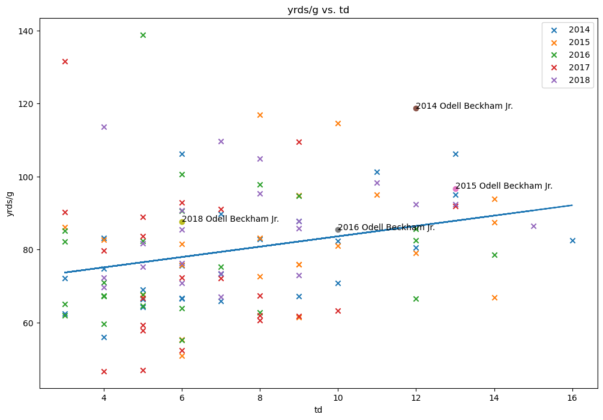

```python
plt.subplots(figsize = (12, 8))

xvar = "td"
yvar = "yrds/g"

i = 2014
for y in table["year"].unique():
    year = table[(table==y).any(axis=1)]
    year = year[~year["Player"].str.contains("Odell Beckham Jr.")]

    plt.scatter(marker="x", x=year[xvar], y=year[yvar], label=str(i))
    i+=1

plt.legend()

for x in table.itertuples():
    name = x[1]
    # y var vs x var
    xvar2 = x[5]
    yvar2 = x[9]
    if(name == "Odell Beckham Jr."):
        plt.scatter(marker="o", x=xvar2, y=yvar2)
        plt.annotate(str(x[12]) + " " + x[1], (xvar2, yvar2))

xvar_reg = np.array(table[xvar]).reshape(-1, 1)
yvar_reg = np.array(table[yvar]).reshape(-1, 1)

reg = LinearRegression().fit(xvar_reg, yvar_reg)
plt.plot(xvar_reg, reg.intercept_ + reg.coef_ * xvar_reg, '-')

plt.xlabel(xvar)
plt.ylabel(yvar)
plt.title(yvar + " vs. " + xvar)
plt.show()
```

This graph visualizes how consistently a receiver is gaining yards and how it relates to their touchdown produciton.

Odell once again performs pretty well, with his first two seasons being notable.

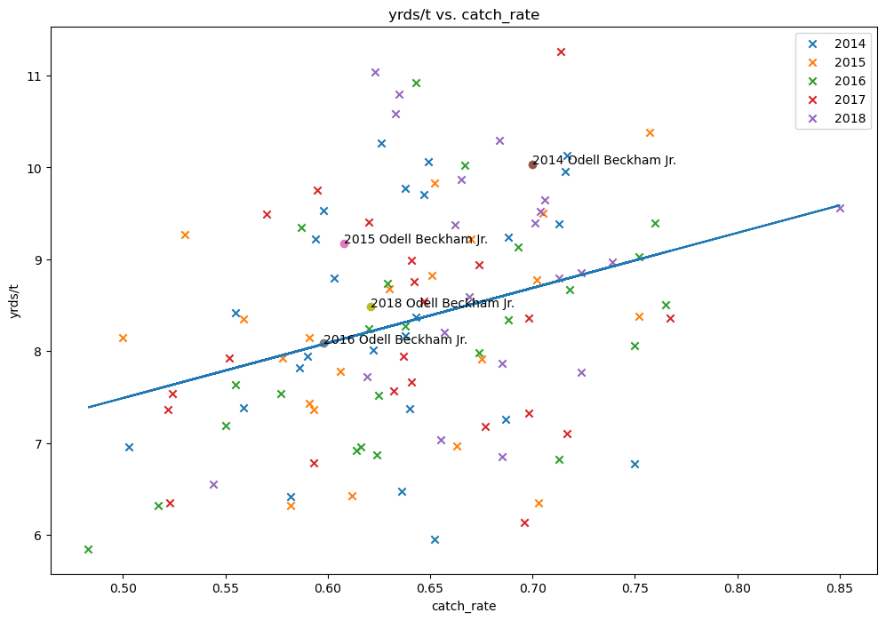

```python
plt.subplots(figsize = (12, 8))

xvar = "catch_rate"
yvar = "yrds/t"

i = 2014
for y in table["year"].unique():
    year = table[(table==y).any(axis=1)]
    year = year[~year["Player"].str.contains("Odell Beckham Jr.")]

    plt.scatter(marker="x", x=year[xvar], y=year[yvar], label=str(i))
    i+=1

plt.legend()

for x in table.itertuples():
    name = x[1]
    # y var vs x var
    xvar2 = x[6]
    yvar2 = x[10]
    if(name == "Odell Beckham Jr."):
        plt.scatter(marker="o", x=xvar2, y=yvar2)
        plt.annotate(str(x[12]) + " " + x[1], (xvar2, yvar2))

xvar_reg = np.array(table[xvar]).reshape(-1, 1)
yvar_reg = np.array(table[yvar]).reshape(-1, 1)

reg = LinearRegression().fit(xvar_reg, yvar_reg)
plt.plot(xvar_reg, reg.intercept_ + reg.coef_ * xvar_reg, '-')

plt.xlabel(xvar)
plt.ylabel(yvar)
plt.title(yvar + " vs. " + xvar)
plt.show()
```

Lastly, this chart analyzes the trade-off between efficiency (yards per target) and accuracy (catch rate).

But what about his performance across the entire 5 year-span?

```python
total = table.groupby("Player", as_index=False).sum()

sumTar = total.sort_values(by=["tar"], ascending=False)
sumRec = total.sort_values(by=["rec"], ascending=False)
sumTD = total.sort_values(by=["td"], ascending=False)
sumYrds = total.sort_values(by=["yrds"], ascending=False)
sumYPG = total.sort_values(by="yrds/g", ascending=False)

key = ['Odell Beckham Jr.']

highlighted_rows = total['Player'].isin(key).map({
    True: 'background-color: lightgreen',
    False: ''
})
```

```python
sumTar.style.apply(lambda _: highlighted_rows)
```

|  | Player | tar | rec | yrds | td | catch_rate | tar/g | rec/g | yrds/g | yrds/t | yrds/r | year |
| --- | --- | --- | --- | --- | --- | --- | --- | --- | --- | --- | --- | --- |
| 8 | Antonio Brown | 859.000000 | 576 | 7646 | 59 | 3.345000 | 56.484524 | 37.776786 | 502.316667 | 44.346615 | 66.410664 | 10080 |
| 31 | Julio Jones | 813.000000 | 524 | 7994 | 31 | 3.211000 | 52.643452 | 33.924405 | 518.842857 | 49.533698 | 77.300363 | 10080 |
| 15 | DeAndre Hopkins | 807.000000 | 476 | 6635 | 45 | 2.951000 | 51.162500 | 30.150000 | 420.429167 | 41.331027 | 69.878256 | 10080 |
| 24 | Jarvis Landry | 719.000000 | 481 | 5014 | 26 | 3.371000 | 50.931818 | 34.154221 | 353.953734 | 35.090263 | 52.488980 | 10080 |
| 16 | Demaryius Thomas | 645.000000 | 389 | 4955 | 27 | 2.414000 | 40.312500 | 24.312500 | 309.687500 | 30.465549 | 50.471701 | 8062 |
| 21 | Golden Tate | 640.000000 | 446 | 5019 | 23 | 3.487000 | 51.580357 | 35.738095 | 398.467262 | 38.966127 | 55.958360 | 10080 |
| 38 | Mike Evans | 595.000000 | 327 | 5052 | 28 | 2.200000 | 39.075595 | 21.394048 | 330.688690 | 34.188259 | 61.877236 | 8066 |
| 40 | Odell Beckham Jr. | 581.000000 | 365 | 5174 | 41 | 2.527000 | 43.247348 | 27.401894 | 388.407197 | 35.788305 | 56.641817 | 8063 |
| 19 | Emmanuel Sanders | 512.000000 | 327 | 4439 | 24 | 2.576000 | 34.608333 | 22.233333 | 300.250000 | 34.693025 | 54.123844 | 8063 |
| 9 | Brandin Cooks | 477.000000 | 307 | 4597 | 29 | 2.572000 | 35.412500 | 22.833333 | 339.966667 | 38.629173 | 60.282234 | 8066 |
| 35 | Larry Fitzgerald | 456.000000 | 325 | 3394 | 21 | 2.142000 | 28.500000 | 20.312500 | 212.125000 | 22.379435 | 31.313041 | 6048 |
| 37 | Michael Thomas | 417.000000 | 321 | 3787 | 23 | 2.308000 | 29.913690 | 22.907738 | 271.491071 | 27.310222 | 35.569849 | 6051 |
| 33 | Keenan Allen | 416.000000 | 276 | 3372 | 16 | 1.991000 | 28.957143 | 19.228571 | 234.223810 | 24.026198 | 36.155591 | 6049 |
| 14 | Davante Adams | 407.000000 | 260 | 3268 | 35 | 1.909000 | 27.690476 | 17.685714 | 222.080952 | 24.004955 | 37.739279 | 6051 |
| 48 | T.Y. Hilton | 406.000000 | 249 | 4063 | 19 | 1.846000 | 26.992262 | 16.582738 | 270.880952 | 30.192444 | 49.025053 | 6048 |
| 30 | Julian Edelman | 401.000000 | 264 | 2928 | 13 | 1.988000 | 31.538462 | 20.782051 | 230.679487 | 22.080077 | 33.337418 | 6048 |
| 46 | Stefon Diggs | 356.000000 | 250 | 2773 | 20 | 2.109000 | 27.610390 | 19.493506 | 215.662338 | 23.851691 | 34.025429 | 6051 |
| 42 | Randall Cobb | 348.000000 | 236 | 2769 | 22 | 2.046000 | 23.108929 | 15.668452 | 182.347024 | 23.658041 | 34.530467 | 6046 |
| 18 | Doug Baldwin | 344.000000 | 247 | 3188 | 29 | 2.156000 | 22.020833 | 15.829167 | 203.950000 | 27.945744 | 38.918462 | 6048 |
| 28 | Jordy Nelson | 303.000000 | 195 | 2776 | 27 | 1.287000 | 18.937500 | 12.187500 | 173.500000 | 18.329339 | 28.458763 | 4030 |
| 3 | Allen Robinson | 302.000000 | 153 | 2283 | 20 | 1.013000 | 18.875000 | 9.562500 | 142.687500 | 15.119205 | 29.595890 | 4031 |
| 2 | Adam Thielen | 295.000000 | 204 | 2649 | 13 | 1.380000 | 18.437500 | 12.750000 | 165.562500 | 17.959772 | 26.172420 | 4035 |
| 36 | Michael Crabtree | 291.000000 | 174 | 1925 | 17 | 1.196000 | 18.795833 | 11.229167 | 124.154167 | 13.232310 | 22.116722 | 4031 |
| 12 | Calvin Johnson | 277.000000 | 159 | 2291 | 17 | 1.146000 | 19.158654 | 10.961538 | 158.721154 | 16.561714 | 28.964469 | 4029 |
| 0 | A.J. Green | 275.000000 | 161 | 2375 | 18 | 1.176000 | 17.187500 | 10.062500 | 148.437500 | 17.364219 | 29.454729 | 4032 |
| 17 | Dez Bryant | 268.000000 | 157 | 2158 | 22 | 1.170000 | 16.750000 | 9.812500 | 134.875000 | 16.054367 | 27.144928 | 4031 |
| 25 | Jeremy Maclin | 267.000000 | 172 | 2406 | 18 | 1.296000 | 17.204167 | 11.112500 | 154.908333 | 17.990977 | 28.011629 | 4029 |
| 20 | Eric Decker | 247.000000 | 154 | 1989 | 17 | 1.249000 | 17.820513 | 11.087179 | 143.133333 | 16.145520 | 25.837500 | 4029 |
| 27 | Jordan Matthews | 243.000000 | 158 | 1801 | 11 | 1.299000 | 19.500000 | 12.698718 | 144.929487 | 14.784493 | 22.743110 | 4031 |
| 51 | Tyreek Hill | 242.000000 | 162 | 2662 | 19 | 1.349000 | 16.639423 | 11.206731 | 183.437500 | 22.062287 | 32.773333 | 4035 |
| 5 | Amari Cooper | 239.000000 | 158 | 2158 | 12 | 1.330000 | 16.561905 | 10.928571 | 149.357143 | 18.127372 | 27.291566 | 4034 |
| 11 | Brandon Marshall | 173.000000 | 109 | 1502 | 14 | 0.630000 | 10.812500 | 6.812500 | 93.875000 | 8.682081 | 13.779817 | 2015 |
| 29 | JuJu Smith-Schuster | 166.000000 | 111 | 1426 | 7 | 0.669000 | 12.769231 | 8.538462 | 109.692308 | 8.590361 | 12.846847 | 2018 |
| 6 | Andre Johnson | 146.000000 | 85 | 936 | 3 | 0.582000 | 9.733333 | 5.666667 | 62.400000 | 6.410959 | 11.011765 | 2014 |
| 34 | Kelvin Benjamin | 145.000000 | 73 | 1008 | 9 | 0.503000 | 9.666667 | 4.866667 | 67.200000 | 6.951724 | 13.808219 | 2014 |
| 4 | Alshon Jeffery | 145.000000 | 85 | 1133 | 10 | 0.586000 | 9.062500 | 5.312500 | 70.812500 | 7.813793 | 13.329412 | 2014 |
| 49 | Terrelle Pryor | 140.000000 | 77 | 1007 | 4 | 0.550000 | 9.333333 | 5.133333 | 67.133333 | 7.192857 | 13.077922 | 2016 |
| 47 | Steve Smith Sr. | 134.000000 | 79 | 1065 | 6 | 0.590000 | 8.375000 | 4.937500 | 66.562500 | 7.947761 | 13.481013 | 2014 |
| 7 | Anquan Boldin | 130.000000 | 83 | 1062 | 5 | 0.638000 | 8.125000 | 5.187500 | 66.375000 | 8.169231 | 12.795181 | 2014 |
| 43 | Robert Woods | 130.000000 | 86 | 1219 | 6 | 0.662000 | 8.125000 | 5.375000 | 76.187500 | 9.376923 | 14.174419 | 2018 |
| 32 | Kamar Aiken | 127.000000 | 75 | 944 | 5 | 0.591000 | 9.071429 | 5.357143 | 67.428571 | 7.433071 | 12.586667 | 2015 |
| 45 | Rueben Randle | 127.000000 | 71 | 938 | 3 | 0.559000 | 9.769231 | 5.461538 | 72.153846 | 7.385827 | 13.211268 | 2014 |
| 44 | Roddy White | 125.000000 | 80 | 921 | 7 | 0.640000 | 8.928571 | 5.714286 | 65.785714 | 7.368000 | 11.512500 | 2014 |
| 10 | Brandon LaFell | 119.000000 | 74 | 953 | 7 | 0.622000 | 9.153846 | 5.692308 | 73.307692 | 8.008403 | 12.878378 | 2014 |
| 41 | Pierre Garcon | 114.000000 | 79 | 1041 | 3 | 0.693000 | 7.125000 | 4.937500 | 65.062500 | 9.131579 | 13.177215 | 2016 |
| 22 | James Jones | 112.000000 | 73 | 666 | 6 | 0.652000 | 11.200000 | 7.300000 | 66.600000 | 5.946429 | 9.123288 | 2014 |
| 50 | Tyler Boyd | 108.000000 | 76 | 1028 | 7 | 0.704000 | 7.714286 | 5.428571 | 73.428571 | 9.518519 | 13.526316 | 2018 |
| 1 | Adam Humphries | 105.000000 | 76 | 816 | 5 | 0.724000 | 10.500000 | 7.600000 | 81.600000 | 7.771429 | 10.736842 | 2018 |
| 23 | Jamison Crowder | 103.000000 | 66 | 789 | 3 | 0.641000 | 17.166667 | 11.000000 | 131.500000 | 7.660194 | 11.954545 | 2017 |
| 26 | Jermaine Kearse | 102.000000 | 65 | 810 | 5 | 0.637000 | 7.285714 | 4.642857 | 57.857143 | 7.941176 | 12.461538 | 2017 |
| 13 | Cole Beasley | 98.000000 | 75 | 833 | 5 | 0.765000 | 16.333333 | 12.500000 | 138.833333 | 8.500000 | 11.106667 | 2016 |
| 39 | Mohamed Sanu | 96.000000 | 67 | 703 | 5 | 0.698000 | 6.400000 | 4.466667 | 46.866667 | 7.322917 | 10.492537 | 2017 |

```python
sumRec.style.apply(lambda _: highlighted_rows)
```

|  | Player | tar | rec | yrds | td | catch_rate | tar/g | rec/g | yrds/g | yrds/t | yrds/r | year |
| --- | --- | --- | --- | --- | --- | --- | --- | --- | --- | --- | --- | --- |
| 8 | Antonio Brown | 859.000000 | 576 | 7646 | 59 | 3.345000 | 56.484524 | 37.776786 | 502.316667 | 44.346615 | 66.410664 | 10080 |
| 31 | Julio Jones | 813.000000 | 524 | 7994 | 31 | 3.211000 | 52.643452 | 33.924405 | 518.842857 | 49.533698 | 77.300363 | 10080 |
| 24 | Jarvis Landry | 719.000000 | 481 | 5014 | 26 | 3.371000 | 50.931818 | 34.154221 | 353.953734 | 35.090263 | 52.488980 | 10080 |
| 15 | DeAndre Hopkins | 807.000000 | 476 | 6635 | 45 | 2.951000 | 51.162500 | 30.150000 | 420.429167 | 41.331027 | 69.878256 | 10080 |
| 21 | Golden Tate | 640.000000 | 446 | 5019 | 23 | 3.487000 | 51.580357 | 35.738095 | 398.467262 | 38.966127 | 55.958360 | 10080 |
| 16 | Demaryius Thomas | 645.000000 | 389 | 4955 | 27 | 2.414000 | 40.312500 | 24.312500 | 309.687500 | 30.465549 | 50.471701 | 8062 |
| 40 | Odell Beckham Jr. | 581.000000 | 365 | 5174 | 41 | 2.527000 | 43.247348 | 27.401894 | 388.407197 | 35.788305 | 56.641817 | 8063 |
| 19 | Emmanuel Sanders | 512.000000 | 327 | 4439 | 24 | 2.576000 | 34.608333 | 22.233333 | 300.250000 | 34.693025 | 54.123844 | 8063 |
| 38 | Mike Evans | 595.000000 | 327 | 5052 | 28 | 2.200000 | 39.075595 | 21.394048 | 330.688690 | 34.188259 | 61.877236 | 8066 |
| 35 | Larry Fitzgerald | 456.000000 | 325 | 3394 | 21 | 2.142000 | 28.500000 | 20.312500 | 212.125000 | 22.379435 | 31.313041 | 6048 |
| 37 | Michael Thomas | 417.000000 | 321 | 3787 | 23 | 2.308000 | 29.913690 | 22.907738 | 271.491071 | 27.310222 | 35.569849 | 6051 |
| 9 | Brandin Cooks | 477.000000 | 307 | 4597 | 29 | 2.572000 | 35.412500 | 22.833333 | 339.966667 | 38.629173 | 60.282234 | 8066 |
| 33 | Keenan Allen | 416.000000 | 276 | 3372 | 16 | 1.991000 | 28.957143 | 19.228571 | 234.223810 | 24.026198 | 36.155591 | 6049 |
| 30 | Julian Edelman | 401.000000 | 264 | 2928 | 13 | 1.988000 | 31.538462 | 20.782051 | 230.679487 | 22.080077 | 33.337418 | 6048 |
| 14 | Davante Adams | 407.000000 | 260 | 3268 | 35 | 1.909000 | 27.690476 | 17.685714 | 222.080952 | 24.004955 | 37.739279 | 6051 |
| 46 | Stefon Diggs | 356.000000 | 250 | 2773 | 20 | 2.109000 | 27.610390 | 19.493506 | 215.662338 | 23.851691 | 34.025429 | 6051 |
| 48 | T.Y. Hilton | 406.000000 | 249 | 4063 | 19 | 1.846000 | 26.992262 | 16.582738 | 270.880952 | 30.192444 | 49.025053 | 6048 |
| 18 | Doug Baldwin | 344.000000 | 247 | 3188 | 29 | 2.156000 | 22.020833 | 15.829167 | 203.950000 | 27.945744 | 38.918462 | 6048 |
| 42 | Randall Cobb | 348.000000 | 236 | 2769 | 22 | 2.046000 | 23.108929 | 15.668452 | 182.347024 | 23.658041 | 34.530467 | 6046 |
| 2 | Adam Thielen | 295.000000 | 204 | 2649 | 13 | 1.380000 | 18.437500 | 12.750000 | 165.562500 | 17.959772 | 26.172420 | 4035 |
| 28 | Jordy Nelson | 303.000000 | 195 | 2776 | 27 | 1.287000 | 18.937500 | 12.187500 | 173.500000 | 18.329339 | 28.458763 | 4030 |
| 36 | Michael Crabtree | 291.000000 | 174 | 1925 | 17 | 1.196000 | 18.795833 | 11.229167 | 124.154167 | 13.232310 | 22.116722 | 4031 |
| 25 | Jeremy Maclin | 267.000000 | 172 | 2406 | 18 | 1.296000 | 17.204167 | 11.112500 | 154.908333 | 17.990977 | 28.011629 | 4029 |
| 51 | Tyreek Hill | 242.000000 | 162 | 2662 | 19 | 1.349000 | 16.639423 | 11.206731 | 183.437500 | 22.062287 | 32.773333 | 4035 |
| 0 | A.J. Green | 275.000000 | 161 | 2375 | 18 | 1.176000 | 17.187500 | 10.062500 | 148.437500 | 17.364219 | 29.454729 | 4032 |
| 12 | Calvin Johnson | 277.000000 | 159 | 2291 | 17 | 1.146000 | 19.158654 | 10.961538 | 158.721154 | 16.561714 | 28.964469 | 4029 |
| 27 | Jordan Matthews | 243.000000 | 158 | 1801 | 11 | 1.299000 | 19.500000 | 12.698718 | 144.929487 | 14.784493 | 22.743110 | 4031 |
| 5 | Amari Cooper | 239.000000 | 158 | 2158 | 12 | 1.330000 | 16.561905 | 10.928571 | 149.357143 | 18.127372 | 27.291566 | 4034 |
| 17 | Dez Bryant | 268.000000 | 157 | 2158 | 22 | 1.170000 | 16.750000 | 9.812500 | 134.875000 | 16.054367 | 27.144928 | 4031 |
| 20 | Eric Decker | 247.000000 | 154 | 1989 | 17 | 1.249000 | 17.820513 | 11.087179 | 143.133333 | 16.145520 | 25.837500 | 4029 |
| 3 | Allen Robinson | 302.000000 | 153 | 2283 | 20 | 1.013000 | 18.875000 | 9.562500 | 142.687500 | 15.119205 | 29.595890 | 4031 |
| 29 | JuJu Smith-Schuster | 166.000000 | 111 | 1426 | 7 | 0.669000 | 12.769231 | 8.538462 | 109.692308 | 8.590361 | 12.846847 | 2018 |
| 11 | Brandon Marshall | 173.000000 | 109 | 1502 | 14 | 0.630000 | 10.812500 | 6.812500 | 93.875000 | 8.682081 | 13.779817 | 2015 |
| 43 | Robert Woods | 130.000000 | 86 | 1219 | 6 | 0.662000 | 8.125000 | 5.375000 | 76.187500 | 9.376923 | 14.174419 | 2018 |
| 6 | Andre Johnson | 146.000000 | 85 | 936 | 3 | 0.582000 | 9.733333 | 5.666667 | 62.400000 | 6.410959 | 11.011765 | 2014 |
| 4 | Alshon Jeffery | 145.000000 | 85 | 1133 | 10 | 0.586000 | 9.062500 | 5.312500 | 70.812500 | 7.813793 | 13.329412 | 2014 |
| 7 | Anquan Boldin | 130.000000 | 83 | 1062 | 5 | 0.638000 | 8.125000 | 5.187500 | 66.375000 | 8.169231 | 12.795181 | 2014 |
| 44 | Roddy White | 125.000000 | 80 | 921 | 7 | 0.640000 | 8.928571 | 5.714286 | 65.785714 | 7.368000 | 11.512500 | 2014 |
| 47 | Steve Smith Sr. | 134.000000 | 79 | 1065 | 6 | 0.590000 | 8.375000 | 4.937500 | 66.562500 | 7.947761 | 13.481013 | 2014 |
| 41 | Pierre Garcon | 114.000000 | 79 | 1041 | 3 | 0.693000 | 7.125000 | 4.937500 | 65.062500 | 9.131579 | 13.177215 | 2016 |
| 49 | Terrelle Pryor | 140.000000 | 77 | 1007 | 4 | 0.550000 | 9.333333 | 5.133333 | 67.133333 | 7.192857 | 13.077922 | 2016 |
| 1 | Adam Humphries | 105.000000 | 76 | 816 | 5 | 0.724000 | 10.500000 | 7.600000 | 81.600000 | 7.771429 | 10.736842 | 2018 |
| 50 | Tyler Boyd | 108.000000 | 76 | 1028 | 7 | 0.704000 | 7.714286 | 5.428571 | 73.428571 | 9.518519 | 13.526316 | 2018 |
| 13 | Cole Beasley | 98.000000 | 75 | 833 | 5 | 0.765000 | 16.333333 | 12.500000 | 138.833333 | 8.500000 | 11.106667 | 2016 |
| 32 | Kamar Aiken | 127.000000 | 75 | 944 | 5 | 0.591000 | 9.071429 | 5.357143 | 67.428571 | 7.433071 | 12.586667 | 2015 |
| 10 | Brandon LaFell | 119.000000 | 74 | 953 | 7 | 0.622000 | 9.153846 | 5.692308 | 73.307692 | 8.008403 | 12.878378 | 2014 |
| 34 | Kelvin Benjamin | 145.000000 | 73 | 1008 | 9 | 0.503000 | 9.666667 | 4.866667 | 67.200000 | 6.951724 | 13.808219 | 2014 |
| 22 | James Jones | 112.000000 | 73 | 666 | 6 | 0.652000 | 11.200000 | 7.300000 | 66.600000 | 5.946429 | 9.123288 | 2014 |
| 45 | Rueben Randle | 127.000000 | 71 | 938 | 3 | 0.559000 | 9.769231 | 5.461538 | 72.153846 | 7.385827 | 13.211268 | 2014 |
| 39 | Mohamed Sanu | 96.000000 | 67 | 703 | 5 | 0.698000 | 6.400000 | 4.466667 | 46.866667 | 7.322917 | 10.492537 | 2017 |
| 23 | Jamison Crowder | 103.000000 | 66 | 789 | 3 | 0.641000 | 17.166667 | 11.000000 | 131.500000 | 7.660194 | 11.954545 | 2017 |
| 26 | Jermaine Kearse | 102.000000 | 65 | 810 | 5 | 0.637000 | 7.285714 | 4.642857 | 57.857143 | 7.941176 | 12.461538 | 2017 |

```python
sumTD.style.apply(lambda _: highlighted_rows)
```

|  | Player | tar | rec | yrds | td | catch_rate | tar/g | rec/g | yrds/g | yrds/t | yrds/r | year |
| --- | --- | --- | --- | --- | --- | --- | --- | --- | --- | --- | --- | --- |
| 8 | Antonio Brown | 859.000000 | 576 | 7646 | 59 | 3.345000 | 56.484524 | 37.776786 | 502.316667 | 44.346615 | 66.410664 | 10080 |
| 15 | DeAndre Hopkins | 807.000000 | 476 | 6635 | 45 | 2.951000 | 51.162500 | 30.150000 | 420.429167 | 41.331027 | 69.878256 | 10080 |
| 40 | Odell Beckham Jr. | 581.000000 | 365 | 5174 | 41 | 2.527000 | 43.247348 | 27.401894 | 388.407197 | 35.788305 | 56.641817 | 8063 |
| 14 | Davante Adams | 407.000000 | 260 | 3268 | 35 | 1.909000 | 27.690476 | 17.685714 | 222.080952 | 24.004955 | 37.739279 | 6051 |
| 31 | Julio Jones | 813.000000 | 524 | 7994 | 31 | 3.211000 | 52.643452 | 33.924405 | 518.842857 | 49.533698 | 77.300363 | 10080 |
| 18 | Doug Baldwin | 344.000000 | 247 | 3188 | 29 | 2.156000 | 22.020833 | 15.829167 | 203.950000 | 27.945744 | 38.918462 | 6048 |
| 9 | Brandin Cooks | 477.000000 | 307 | 4597 | 29 | 2.572000 | 35.412500 | 22.833333 | 339.966667 | 38.629173 | 60.282234 | 8066 |
| 38 | Mike Evans | 595.000000 | 327 | 5052 | 28 | 2.200000 | 39.075595 | 21.394048 | 330.688690 | 34.188259 | 61.877236 | 8066 |
| 16 | Demaryius Thomas | 645.000000 | 389 | 4955 | 27 | 2.414000 | 40.312500 | 24.312500 | 309.687500 | 30.465549 | 50.471701 | 8062 |
| 28 | Jordy Nelson | 303.000000 | 195 | 2776 | 27 | 1.287000 | 18.937500 | 12.187500 | 173.500000 | 18.329339 | 28.458763 | 4030 |
| 24 | Jarvis Landry | 719.000000 | 481 | 5014 | 26 | 3.371000 | 50.931818 | 34.154221 | 353.953734 | 35.090263 | 52.488980 | 10080 |
| 19 | Emmanuel Sanders | 512.000000 | 327 | 4439 | 24 | 2.576000 | 34.608333 | 22.233333 | 300.250000 | 34.693025 | 54.123844 | 8063 |
| 21 | Golden Tate | 640.000000 | 446 | 5019 | 23 | 3.487000 | 51.580357 | 35.738095 | 398.467262 | 38.966127 | 55.958360 | 10080 |
| 37 | Michael Thomas | 417.000000 | 321 | 3787 | 23 | 2.308000 | 29.913690 | 22.907738 | 271.491071 | 27.310222 | 35.569849 | 6051 |
| 17 | Dez Bryant | 268.000000 | 157 | 2158 | 22 | 1.170000 | 16.750000 | 9.812500 | 134.875000 | 16.054367 | 27.144928 | 4031 |
| 42 | Randall Cobb | 348.000000 | 236 | 2769 | 22 | 2.046000 | 23.108929 | 15.668452 | 182.347024 | 23.658041 | 34.530467 | 6046 |
| 35 | Larry Fitzgerald | 456.000000 | 325 | 3394 | 21 | 2.142000 | 28.500000 | 20.312500 | 212.125000 | 22.379435 | 31.313041 | 6048 |
| 46 | Stefon Diggs | 356.000000 | 250 | 2773 | 20 | 2.109000 | 27.610390 | 19.493506 | 215.662338 | 23.851691 | 34.025429 | 6051 |
| 3 | Allen Robinson | 302.000000 | 153 | 2283 | 20 | 1.013000 | 18.875000 | 9.562500 | 142.687500 | 15.119205 | 29.595890 | 4031 |
| 48 | T.Y. Hilton | 406.000000 | 249 | 4063 | 19 | 1.846000 | 26.992262 | 16.582738 | 270.880952 | 30.192444 | 49.025053 | 6048 |
| 51 | Tyreek Hill | 242.000000 | 162 | 2662 | 19 | 1.349000 | 16.639423 | 11.206731 | 183.437500 | 22.062287 | 32.773333 | 4035 |
| 25 | Jeremy Maclin | 267.000000 | 172 | 2406 | 18 | 1.296000 | 17.204167 | 11.112500 | 154.908333 | 17.990977 | 28.011629 | 4029 |
| 0 | A.J. Green | 275.000000 | 161 | 2375 | 18 | 1.176000 | 17.187500 | 10.062500 | 148.437500 | 17.364219 | 29.454729 | 4032 |
| 20 | Eric Decker | 247.000000 | 154 | 1989 | 17 | 1.249000 | 17.820513 | 11.087179 | 143.133333 | 16.145520 | 25.837500 | 4029 |
| 12 | Calvin Johnson | 277.000000 | 159 | 2291 | 17 | 1.146000 | 19.158654 | 10.961538 | 158.721154 | 16.561714 | 28.964469 | 4029 |
| 36 | Michael Crabtree | 291.000000 | 174 | 1925 | 17 | 1.196000 | 18.795833 | 11.229167 | 124.154167 | 13.232310 | 22.116722 | 4031 |
| 33 | Keenan Allen | 416.000000 | 276 | 3372 | 16 | 1.991000 | 28.957143 | 19.228571 | 234.223810 | 24.026198 | 36.155591 | 6049 |
| 11 | Brandon Marshall | 173.000000 | 109 | 1502 | 14 | 0.630000 | 10.812500 | 6.812500 | 93.875000 | 8.682081 | 13.779817 | 2015 |
| 2 | Adam Thielen | 295.000000 | 204 | 2649 | 13 | 1.380000 | 18.437500 | 12.750000 | 165.562500 | 17.959772 | 26.172420 | 4035 |
| 30 | Julian Edelman | 401.000000 | 264 | 2928 | 13 | 1.988000 | 31.538462 | 20.782051 | 230.679487 | 22.080077 | 33.337418 | 6048 |
| 5 | Amari Cooper | 239.000000 | 158 | 2158 | 12 | 1.330000 | 16.561905 | 10.928571 | 149.357143 | 18.127372 | 27.291566 | 4034 |
| 27 | Jordan Matthews | 243.000000 | 158 | 1801 | 11 | 1.299000 | 19.500000 | 12.698718 | 144.929487 | 14.784493 | 22.743110 | 4031 |
| 4 | Alshon Jeffery | 145.000000 | 85 | 1133 | 10 | 0.586000 | 9.062500 | 5.312500 | 70.812500 | 7.813793 | 13.329412 | 2014 |
| 34 | Kelvin Benjamin | 145.000000 | 73 | 1008 | 9 | 0.503000 | 9.666667 | 4.866667 | 67.200000 | 6.951724 | 13.808219 | 2014 |
| 10 | Brandon LaFell | 119.000000 | 74 | 953 | 7 | 0.622000 | 9.153846 | 5.692308 | 73.307692 | 8.008403 | 12.878378 | 2014 |
| 50 | Tyler Boyd | 108.000000 | 76 | 1028 | 7 | 0.704000 | 7.714286 | 5.428571 | 73.428571 | 9.518519 | 13.526316 | 2018 |
| 29 | JuJu Smith-Schuster | 166.000000 | 111 | 1426 | 7 | 0.669000 | 12.769231 | 8.538462 | 109.692308 | 8.590361 | 12.846847 | 2018 |
| 44 | Roddy White | 125.000000 | 80 | 921 | 7 | 0.640000 | 8.928571 | 5.714286 | 65.785714 | 7.368000 | 11.512500 | 2014 |
| 47 | Steve Smith Sr. | 134.000000 | 79 | 1065 | 6 | 0.590000 | 8.375000 | 4.937500 | 66.562500 | 7.947761 | 13.481013 | 2014 |
| 22 | James Jones | 112.000000 | 73 | 666 | 6 | 0.652000 | 11.200000 | 7.300000 | 66.600000 | 5.946429 | 9.123288 | 2014 |
| 43 | Robert Woods | 130.000000 | 86 | 1219 | 6 | 0.662000 | 8.125000 | 5.375000 | 76.187500 | 9.376923 | 14.174419 | 2018 |
| 26 | Jermaine Kearse | 102.000000 | 65 | 810 | 5 | 0.637000 | 7.285714 | 4.642857 | 57.857143 | 7.941176 | 12.461538 | 2017 |
| 39 | Mohamed Sanu | 96.000000 | 67 | 703 | 5 | 0.698000 | 6.400000 | 4.466667 | 46.866667 | 7.322917 | 10.492537 | 2017 |
| 7 | Anquan Boldin | 130.000000 | 83 | 1062 | 5 | 0.638000 | 8.125000 | 5.187500 | 66.375000 | 8.169231 | 12.795181 | 2014 |
| 32 | Kamar Aiken | 127.000000 | 75 | 944 | 5 | 0.591000 | 9.071429 | 5.357143 | 67.428571 | 7.433071 | 12.586667 | 2015 |
| 13 | Cole Beasley | 98.000000 | 75 | 833 | 5 | 0.765000 | 16.333333 | 12.500000 | 138.833333 | 8.500000 | 11.106667 | 2016 |
| 1 | Adam Humphries | 105.000000 | 76 | 816 | 5 | 0.724000 | 10.500000 | 7.600000 | 81.600000 | 7.771429 | 10.736842 | 2018 |
| 49 | Terrelle Pryor | 140.000000 | 77 | 1007 | 4 | 0.550000 | 9.333333 | 5.133333 | 67.133333 | 7.192857 | 13.077922 | 2016 |
| 41 | Pierre Garcon | 114.000000 | 79 | 1041 | 3 | 0.693000 | 7.125000 | 4.937500 | 65.062500 | 9.131579 | 13.177215 | 2016 |
| 6 | Andre Johnson | 146.000000 | 85 | 936 | 3 | 0.582000 | 9.733333 | 5.666667 | 62.400000 | 6.410959 | 11.011765 | 2014 |
| 45 | Rueben Randle | 127.000000 | 71 | 938 | 3 | 0.559000 | 9.769231 | 5.461538 | 72.153846 | 7.385827 | 13.211268 | 2014 |
| 23 | Jamison Crowder | 103.000000 | 66 | 789 | 3 | 0.641000 | 17.166667 | 11.000000 | 131.500000 | 7.660194 | 11.954545 | 2017 |

```python
sumYrds.style.apply(lambda _: highlighted_rows)
```

|  | Player | tar | rec | yrds | td | catch_rate | tar/g | rec/g | yrds/g | yrds/t | yrds/r | year |
| --- | --- | --- | --- | --- | --- | --- | --- | --- | --- | --- | --- | --- |
| 31 | Julio Jones | 813.000000 | 524 | 7994 | 31 | 3.211000 | 52.643452 | 33.924405 | 518.842857 | 49.533698 | 77.300363 | 10080 |
| 8 | Antonio Brown | 859.000000 | 576 | 7646 | 59 | 3.345000 | 56.484524 | 37.776786 | 502.316667 | 44.346615 | 66.410664 | 10080 |
| 15 | DeAndre Hopkins | 807.000000 | 476 | 6635 | 45 | 2.951000 | 51.162500 | 30.150000 | 420.429167 | 41.331027 | 69.878256 | 10080 |
| 40 | Odell Beckham Jr. | 581.000000 | 365 | 5174 | 41 | 2.527000 | 43.247348 | 27.401894 | 388.407197 | 35.788305 | 56.641817 | 8063 |
| 38 | Mike Evans | 595.000000 | 327 | 5052 | 28 | 2.200000 | 39.075595 | 21.394048 | 330.688690 | 34.188259 | 61.877236 | 8066 |
| 21 | Golden Tate | 640.000000 | 446 | 5019 | 23 | 3.487000 | 51.580357 | 35.738095 | 398.467262 | 38.966127 | 55.958360 | 10080 |
| 24 | Jarvis Landry | 719.000000 | 481 | 5014 | 26 | 3.371000 | 50.931818 | 34.154221 | 353.953734 | 35.090263 | 52.488980 | 10080 |
| 16 | Demaryius Thomas | 645.000000 | 389 | 4955 | 27 | 2.414000 | 40.312500 | 24.312500 | 309.687500 | 30.465549 | 50.471701 | 8062 |
| 9 | Brandin Cooks | 477.000000 | 307 | 4597 | 29 | 2.572000 | 35.412500 | 22.833333 | 339.966667 | 38.629173 | 60.282234 | 8066 |
| 19 | Emmanuel Sanders | 512.000000 | 327 | 4439 | 24 | 2.576000 | 34.608333 | 22.233333 | 300.250000 | 34.693025 | 54.123844 | 8063 |
| 48 | T.Y. Hilton | 406.000000 | 249 | 4063 | 19 | 1.846000 | 26.992262 | 16.582738 | 270.880952 | 30.192444 | 49.025053 | 6048 |
| 37 | Michael Thomas | 417.000000 | 321 | 3787 | 23 | 2.308000 | 29.913690 | 22.907738 | 271.491071 | 27.310222 | 35.569849 | 6051 |
| 35 | Larry Fitzgerald | 456.000000 | 325 | 3394 | 21 | 2.142000 | 28.500000 | 20.312500 | 212.125000 | 22.379435 | 31.313041 | 6048 |
| 33 | Keenan Allen | 416.000000 | 276 | 3372 | 16 | 1.991000 | 28.957143 | 19.228571 | 234.223810 | 24.026198 | 36.155591 | 6049 |
| 14 | Davante Adams | 407.000000 | 260 | 3268 | 35 | 1.909000 | 27.690476 | 17.685714 | 222.080952 | 24.004955 | 37.739279 | 6051 |
| 18 | Doug Baldwin | 344.000000 | 247 | 3188 | 29 | 2.156000 | 22.020833 | 15.829167 | 203.950000 | 27.945744 | 38.918462 | 6048 |
| 30 | Julian Edelman | 401.000000 | 264 | 2928 | 13 | 1.988000 | 31.538462 | 20.782051 | 230.679487 | 22.080077 | 33.337418 | 6048 |
| 28 | Jordy Nelson | 303.000000 | 195 | 2776 | 27 | 1.287000 | 18.937500 | 12.187500 | 173.500000 | 18.329339 | 28.458763 | 4030 |
| 46 | Stefon Diggs | 356.000000 | 250 | 2773 | 20 | 2.109000 | 27.610390 | 19.493506 | 215.662338 | 23.851691 | 34.025429 | 6051 |
| 42 | Randall Cobb | 348.000000 | 236 | 2769 | 22 | 2.046000 | 23.108929 | 15.668452 | 182.347024 | 23.658041 | 34.530467 | 6046 |
| 51 | Tyreek Hill | 242.000000 | 162 | 2662 | 19 | 1.349000 | 16.639423 | 11.206731 | 183.437500 | 22.062287 | 32.773333 | 4035 |
| 2 | Adam Thielen | 295.000000 | 204 | 2649 | 13 | 1.380000 | 18.437500 | 12.750000 | 165.562500 | 17.959772 | 26.172420 | 4035 |
| 25 | Jeremy Maclin | 267.000000 | 172 | 2406 | 18 | 1.296000 | 17.204167 | 11.112500 | 154.908333 | 17.990977 | 28.011629 | 4029 |
| 0 | A.J. Green | 275.000000 | 161 | 2375 | 18 | 1.176000 | 17.187500 | 10.062500 | 148.437500 | 17.364219 | 29.454729 | 4032 |
| 12 | Calvin Johnson | 277.000000 | 159 | 2291 | 17 | 1.146000 | 19.158654 | 10.961538 | 158.721154 | 16.561714 | 28.964469 | 4029 |
| 3 | Allen Robinson | 302.000000 | 153 | 2283 | 20 | 1.013000 | 18.875000 | 9.562500 | 142.687500 | 15.119205 | 29.595890 | 4031 |
| 17 | Dez Bryant | 268.000000 | 157 | 2158 | 22 | 1.170000 | 16.750000 | 9.812500 | 134.875000 | 16.054367 | 27.144928 | 4031 |
| 5 | Amari Cooper | 239.000000 | 158 | 2158 | 12 | 1.330000 | 16.561905 | 10.928571 | 149.357143 | 18.127372 | 27.291566 | 4034 |
| 20 | Eric Decker | 247.000000 | 154 | 1989 | 17 | 1.249000 | 17.820513 | 11.087179 | 143.133333 | 16.145520 | 25.837500 | 4029 |
| 36 | Michael Crabtree | 291.000000 | 174 | 1925 | 17 | 1.196000 | 18.795833 | 11.229167 | 124.154167 | 13.232310 | 22.116722 | 4031 |
| 27 | Jordan Matthews | 243.000000 | 158 | 1801 | 11 | 1.299000 | 19.500000 | 12.698718 | 144.929487 | 14.784493 | 22.743110 | 4031 |
| 11 | Brandon Marshall | 173.000000 | 109 | 1502 | 14 | 0.630000 | 10.812500 | 6.812500 | 93.875000 | 8.682081 | 13.779817 | 2015 |
| 29 | JuJu Smith-Schuster | 166.000000 | 111 | 1426 | 7 | 0.669000 | 12.769231 | 8.538462 | 109.692308 | 8.590361 | 12.846847 | 2018 |
| 43 | Robert Woods | 130.000000 | 86 | 1219 | 6 | 0.662000 | 8.125000 | 5.375000 | 76.187500 | 9.376923 | 14.174419 | 2018 |
| 4 | Alshon Jeffery | 145.000000 | 85 | 1133 | 10 | 0.586000 | 9.062500 | 5.312500 | 70.812500 | 7.813793 | 13.329412 | 2014 |
| 47 | Steve Smith Sr. | 134.000000 | 79 | 1065 | 6 | 0.590000 | 8.375000 | 4.937500 | 66.562500 | 7.947761 | 13.481013 | 2014 |
| 7 | Anquan Boldin | 130.000000 | 83 | 1062 | 5 | 0.638000 | 8.125000 | 5.187500 | 66.375000 | 8.169231 | 12.795181 | 2014 |
| 41 | Pierre Garcon | 114.000000 | 79 | 1041 | 3 | 0.693000 | 7.125000 | 4.937500 | 65.062500 | 9.131579 | 13.177215 | 2016 |
| 50 | Tyler Boyd | 108.000000 | 76 | 1028 | 7 | 0.704000 | 7.714286 | 5.428571 | 73.428571 | 9.518519 | 13.526316 | 2018 |
| 34 | Kelvin Benjamin | 145.000000 | 73 | 1008 | 9 | 0.503000 | 9.666667 | 4.866667 | 67.200000 | 6.951724 | 13.808219 | 2014 |
| 49 | Terrelle Pryor | 140.000000 | 77 | 1007 | 4 | 0.550000 | 9.333333 | 5.133333 | 67.133333 | 7.192857 | 13.077922 | 2016 |
| 10 | Brandon LaFell | 119.000000 | 74 | 953 | 7 | 0.622000 | 9.153846 | 5.692308 | 73.307692 | 8.008403 | 12.878378 | 2014 |
| 32 | Kamar Aiken | 127.000000 | 75 | 944 | 5 | 0.591000 | 9.071429 | 5.357143 | 67.428571 | 7.433071 | 12.586667 | 2015 |
| 45 | Rueben Randle | 127.000000 | 71 | 938 | 3 | 0.559000 | 9.769231 | 5.461538 | 72.153846 | 7.385827 | 13.211268 | 2014 |
| 6 | Andre Johnson | 146.000000 | 85 | 936 | 3 | 0.582000 | 9.733333 | 5.666667 | 62.400000 | 6.410959 | 11.011765 | 2014 |
| 44 | Roddy White | 125.000000 | 80 | 921 | 7 | 0.640000 | 8.928571 | 5.714286 | 65.785714 | 7.368000 | 11.512500 | 2014 |
| 13 | Cole Beasley | 98.000000 | 75 | 833 | 5 | 0.765000 | 16.333333 | 12.500000 | 138.833333 | 8.500000 | 11.106667 | 2016 |
| 1 | Adam Humphries | 105.000000 | 76 | 816 | 5 | 0.724000 | 10.500000 | 7.600000 | 81.600000 | 7.771429 | 10.736842 | 2018 |
| 26 | Jermaine Kearse | 102.000000 | 65 | 810 | 5 | 0.637000 | 7.285714 | 4.642857 | 57.857143 | 7.941176 | 12.461538 | 2017 |
| 23 | Jamison Crowder | 103.000000 | 66 | 789 | 3 | 0.641000 | 17.166667 | 11.000000 | 131.500000 | 7.660194 | 11.954545 | 2017 |
| 39 | Mohamed Sanu | 96.000000 | 67 | 703 | 5 | 0.698000 | 6.400000 | 4.466667 | 46.866667 | 7.322917 | 10.492537 | 2017 |
| 22 | James Jones | 112.000000 | 73 | 666 | 6 | 0.652000 | 11.200000 | 7.300000 | 66.600000 | 5.946429 | 9.123288 | 2014 |

```python
sumYPG.style.apply(lambda _: highlighted_rows)
```

|  | Player | tar | rec | yrds | td | catch_rate | tar/g | rec/g | yrds/g | yrds/t | yrds/r | year |
| --- | --- | --- | --- | --- | --- | --- | --- | --- | --- | --- | --- | --- |
| 31 | Julio Jones | 813.000000 | 524 | 7994 | 31 | 3.211000 | 52.643452 | 33.924405 | 518.842857 | 49.533698 | 77.300363 | 10080 |
| 8 | Antonio Brown | 859.000000 | 576 | 7646 | 59 | 3.345000 | 56.484524 | 37.776786 | 502.316667 | 44.346615 | 66.410664 | 10080 |
| 15 | DeAndre Hopkins | 807.000000 | 476 | 6635 | 45 | 2.951000 | 51.162500 | 30.150000 | 420.429167 | 41.331027 | 69.878256 | 10080 |
| 21 | Golden Tate | 640.000000 | 446 | 5019 | 23 | 3.487000 | 51.580357 | 35.738095 | 398.467262 | 38.966127 | 55.958360 | 10080 |
| 40 | Odell Beckham Jr. | 581.000000 | 365 | 5174 | 41 | 2.527000 | 43.247348 | 27.401894 | 388.407197 | 35.788305 | 56.641817 | 8063 |
| 24 | Jarvis Landry | 719.000000 | 481 | 5014 | 26 | 3.371000 | 50.931818 | 34.154221 | 353.953734 | 35.090263 | 52.488980 | 10080 |
| 9 | Brandin Cooks | 477.000000 | 307 | 4597 | 29 | 2.572000 | 35.412500 | 22.833333 | 339.966667 | 38.629173 | 60.282234 | 8066 |
| 38 | Mike Evans | 595.000000 | 327 | 5052 | 28 | 2.200000 | 39.075595 | 21.394048 | 330.688690 | 34.188259 | 61.877236 | 8066 |
| 16 | Demaryius Thomas | 645.000000 | 389 | 4955 | 27 | 2.414000 | 40.312500 | 24.312500 | 309.687500 | 30.465549 | 50.471701 | 8062 |
| 19 | Emmanuel Sanders | 512.000000 | 327 | 4439 | 24 | 2.576000 | 34.608333 | 22.233333 | 300.250000 | 34.693025 | 54.123844 | 8063 |
| 37 | Michael Thomas | 417.000000 | 321 | 3787 | 23 | 2.308000 | 29.913690 | 22.907738 | 271.491071 | 27.310222 | 35.569849 | 6051 |
| 48 | T.Y. Hilton | 406.000000 | 249 | 4063 | 19 | 1.846000 | 26.992262 | 16.582738 | 270.880952 | 30.192444 | 49.025053 | 6048 |
| 33 | Keenan Allen | 416.000000 | 276 | 3372 | 16 | 1.991000 | 28.957143 | 19.228571 | 234.223810 | 24.026198 | 36.155591 | 6049 |
| 30 | Julian Edelman | 401.000000 | 264 | 2928 | 13 | 1.988000 | 31.538462 | 20.782051 | 230.679487 | 22.080077 | 33.337418 | 6048 |
| 14 | Davante Adams | 407.000000 | 260 | 3268 | 35 | 1.909000 | 27.690476 | 17.685714 | 222.080952 | 24.004955 | 37.739279 | 6051 |
| 46 | Stefon Diggs | 356.000000 | 250 | 2773 | 20 | 2.109000 | 27.610390 | 19.493506 | 215.662338 | 23.851691 | 34.025429 | 6051 |
| 35 | Larry Fitzgerald | 456.000000 | 325 | 3394 | 21 | 2.142000 | 28.500000 | 20.312500 | 212.125000 | 22.379435 | 31.313041 | 6048 |
| 18 | Doug Baldwin | 344.000000 | 247 | 3188 | 29 | 2.156000 | 22.020833 | 15.829167 | 203.950000 | 27.945744 | 38.918462 | 6048 |
| 51 | Tyreek Hill | 242.000000 | 162 | 2662 | 19 | 1.349000 | 16.639423 | 11.206731 | 183.437500 | 22.062287 | 32.773333 | 4035 |
| 42 | Randall Cobb | 348.000000 | 236 | 2769 | 22 | 2.046000 | 23.108929 | 15.668452 | 182.347024 | 23.658041 | 34.530467 | 6046 |
| 28 | Jordy Nelson | 303.000000 | 195 | 2776 | 27 | 1.287000 | 18.937500 | 12.187500 | 173.500000 | 18.329339 | 28.458763 | 4030 |
| 2 | Adam Thielen | 295.000000 | 204 | 2649 | 13 | 1.380000 | 18.437500 | 12.750000 | 165.562500 | 17.959772 | 26.172420 | 4035 |
| 12 | Calvin Johnson | 277.000000 | 159 | 2291 | 17 | 1.146000 | 19.158654 | 10.961538 | 158.721154 | 16.561714 | 28.964469 | 4029 |
| 25 | Jeremy Maclin | 267.000000 | 172 | 2406 | 18 | 1.296000 | 17.204167 | 11.112500 | 154.908333 | 17.990977 | 28.011629 | 4029 |
| 5 | Amari Cooper | 239.000000 | 158 | 2158 | 12 | 1.330000 | 16.561905 | 10.928571 | 149.357143 | 18.127372 | 27.291566 | 4034 |
| 0 | A.J. Green | 275.000000 | 161 | 2375 | 18 | 1.176000 | 17.187500 | 10.062500 | 148.437500 | 17.364219 | 29.454729 | 4032 |
| 27 | Jordan Matthews | 243.000000 | 158 | 1801 | 11 | 1.299000 | 19.500000 | 12.698718 | 144.929487 | 14.784493 | 22.743110 | 4031 |
| 20 | Eric Decker | 247.000000 | 154 | 1989 | 17 | 1.249000 | 17.820513 | 11.087179 | 143.133333 | 16.145520 | 25.837500 | 4029 |
| 3 | Allen Robinson | 302.000000 | 153 | 2283 | 20 | 1.013000 | 18.875000 | 9.562500 | 142.687500 | 15.119205 | 29.595890 | 4031 |
| 13 | Cole Beasley | 98.000000 | 75 | 833 | 5 | 0.765000 | 16.333333 | 12.500000 | 138.833333 | 8.500000 | 11.106667 | 2016 |
| 17 | Dez Bryant | 268.000000 | 157 | 2158 | 22 | 1.170000 | 16.750000 | 9.812500 | 134.875000 | 16.054367 | 27.144928 | 4031 |
| 23 | Jamison Crowder | 103.000000 | 66 | 789 | 3 | 0.641000 | 17.166667 | 11.000000 | 131.500000 | 7.660194 | 11.954545 | 2017 |
| 36 | Michael Crabtree | 291.000000 | 174 | 1925 | 17 | 1.196000 | 18.795833 | 11.229167 | 124.154167 | 13.232310 | 22.116722 | 4031 |
| 29 | JuJu Smith-Schuster | 166.000000 | 111 | 1426 | 7 | 0.669000 | 12.769231 | 8.538462 | 109.692308 | 8.590361 | 12.846847 | 2018 |
| 11 | Brandon Marshall | 173.000000 | 109 | 1502 | 14 | 0.630000 | 10.812500 | 6.812500 | 93.875000 | 8.682081 | 13.779817 | 2015 |
| 1 | Adam Humphries | 105.000000 | 76 | 816 | 5 | 0.724000 | 10.500000 | 7.600000 | 81.600000 | 7.771429 | 10.736842 | 2018 |
| 43 | Robert Woods | 130.000000 | 86 | 1219 | 6 | 0.662000 | 8.125000 | 5.375000 | 76.187500 | 9.376923 | 14.174419 | 2018 |
| 50 | Tyler Boyd | 108.000000 | 76 | 1028 | 7 | 0.704000 | 7.714286 | 5.428571 | 73.428571 | 9.518519 | 13.526316 | 2018 |
| 10 | Brandon LaFell | 119.000000 | 74 | 953 | 7 | 0.622000 | 9.153846 | 5.692308 | 73.307692 | 8.008403 | 12.878378 | 2014 |
| 45 | Rueben Randle | 127.000000 | 71 | 938 | 3 | 0.559000 | 9.769231 | 5.461538 | 72.153846 | 7.385827 | 13.211268 | 2014 |
| 4 | Alshon Jeffery | 145.000000 | 85 | 1133 | 10 | 0.586000 | 9.062500 | 5.312500 | 70.812500 | 7.813793 | 13.329412 | 2014 |
| 32 | Kamar Aiken | 127.000000 | 75 | 944 | 5 | 0.591000 | 9.071429 | 5.357143 | 67.428571 | 7.433071 | 12.586667 | 2015 |
| 34 | Kelvin Benjamin | 145.000000 | 73 | 1008 | 9 | 0.503000 | 9.666667 | 4.866667 | 67.200000 | 6.951724 | 13.808219 | 2014 |
| 49 | Terrelle Pryor | 140.000000 | 77 | 1007 | 4 | 0.550000 | 9.333333 | 5.133333 | 67.133333 | 7.192857 | 13.077922 | 2016 |
| 22 | James Jones | 112.000000 | 73 | 666 | 6 | 0.652000 | 11.200000 | 7.300000 | 66.600000 | 5.946429 | 9.123288 | 2014 |
| 47 | Steve Smith Sr. | 134.000000 | 79 | 1065 | 6 | 0.590000 | 8.375000 | 4.937500 | 66.562500 | 7.947761 | 13.481013 | 2014 |
| 7 | Anquan Boldin | 130.000000 | 83 | 1062 | 5 | 0.638000 | 8.125000 | 5.187500 | 66.375000 | 8.169231 | 12.795181 | 2014 |
| 44 | Roddy White | 125.000000 | 80 | 921 | 7 | 0.640000 | 8.928571 | 5.714286 | 65.785714 | 7.368000 | 11.512500 | 2014 |
| 41 | Pierre Garcon | 114.000000 | 79 | 1041 | 3 | 0.693000 | 7.125000 | 4.937500 | 65.062500 | 9.131579 | 13.177215 | 2016 |
| 6 | Andre Johnson | 146.000000 | 85 | 936 | 3 | 0.582000 | 9.733333 | 5.666667 | 62.400000 | 6.410959 | 11.011765 | 2014 |
| 26 | Jermaine Kearse | 102.000000 | 65 | 810 | 5 | 0.637000 | 7.285714 | 4.642857 | 57.857143 | 7.941176 | 12.461538 | 2017 |
| 39 | Mohamed Sanu | 96.000000 | 67 | 703 | 5 | 0.698000 | 6.400000 | 4.466667 | 46.866667 | 7.322917 | 10.492537 | 2017 |

## Conclusion

```python
odell = table[table["Player"].str.contains("Odell Beckham Jr.")]
odell
```

|  | Player | tar | rec | yrds | td | catch_rate | tar/g | rec/g | yrds/g | yrds/t | yrds/r | year |
| --- | --- | --- | --- | --- | --- | --- | --- | --- | --- | --- | --- | --- |
| 8 | Odell Beckham Jr. | 130.0 | 91 | 1305 | 12 | 0.700 | 11.818182 | 8.272727 | 118.636364 | 10.038462 | 14.340659 | 2014 |
| 7 | Odell Beckham Jr. | 158.0 | 96 | 1450 | 13 | 0.608 | 10.533333 | 6.400000 | 96.666667 | 9.177215 | 15.104167 | 2015 |
| 2 | Odell Beckham Jr. | 169.0 | 101 | 1367 | 10 | 0.598 | 10.562500 | 6.312500 | 85.437500 | 8.088757 | 13.534653 | 2016 |
| 21 | Odell Beckham Jr. | 124.0 | 77 | 1052 | 6 | 0.621 | 10.333333 | 6.416667 | 87.666667 | 8.483871 | 13.662338 | 2018 |

#### So just how good was Odell as a New York Giant?

All while dealing with an ACL tear and missing 13 games. That is not even to take account how poor the Giants' overall performance during that time period was. He also finished with 90+ receptions in 3/4 seasons, 1,000+ receiving yards in all 4, and 10+ touchdowns in 3/4 seasons.

Of course there are other factors to consider when analyzing a wide receiver's performance. But the numbers alone suggest Odell Beckham Jr. was a very good receiver with the Giants.